# project1

Austin Melendez

2026-03-21

```r
#install.packages("ISLR2")
#install.packages("tidyverse")
#install.packages("MASS")
#install.packages("class")
#install.packages("e1071")

library(ISLR2)
library(tidyverse)
library(MASS)
library(class)
library(e1071)
```

# 1. Dataset Description

This project uses the [Congressional Voting Records Dataset](https://archive.ics.uci.edu/dataset/105/congressional+voting+records), available from the UCI Machine Learning Repository:

https://archive.ics.uci.edu/dataset/105/congressional+voting+records

### Overview:

- Observations: 435 members of the U.S. House of Representatives
- Response Variable: Class Name (Democrat or Republican)
- Attributes: 16 key votes on issues (El Salvador aid, education spending, etc.)
  - Values:
    - y = yes
    - n = no
    - ? = abstention/absence

The data dictionary, `.names` file, describes the attribute information:

- Class Name: 2 (democrat, republican)
- handicapped-infants: 2 (y,n)
- water-project-cost-sharing: 2 (y,n)
- adoption-of-the-budget-resolution: 2 (y,n)
- physician-fee-freeze: 2 (y,n)
- el-salvador-aid: 2 (y,n)
- religious-groups-in-schools: 2 (y,n)
- anti-satellite-test-ban: 2 (y,n)
- aid-to-nicaraguan-contras: 2 (y,n)
- mx-missile: 2 (y,n)
- immigration: 2 (y,n)
- synfuels-corporation-cutback: 2 (y,n)
- education-spending: 2 (y,n)
- superfund-right-to-sue: 2 (y,n)
- crime: 2 (y,n)
- duty-free-exports: 2 (y,n)
- export-administration-act-south-africa: 2 (y,n)

### Goal:

We want to *predict party affiliation* based on their voting patterns.

# 2. Importing the Data

```r
library(tidyverse)

# Load data
url <- "https://archive.ics.uci.edu/ml/machine-learning-databases/voting-records/house-votes-84.data"

votes <- read.csv(url, header = FALSE)

# Assign column names
colnames(votes) <- c("party","handicapped-infants","water-project-cost-sharing","adoption-of-budget-resolution","physician-fee-freeze","el-salvador-aid","religious-groups-in-schools","anti-satellite-test-ban","aid-to-nicaraguan-contras","mx-missile","immigration","synfuels-corporation-cutback","education-spending","superfund-right-to-sue","crime","duty-free-exports","export-administration-act")
```

I have to manually assign column names because the dataset does not include headers in their `.data` file. Luckily their `.names` file contains the data dictionary which provides the column names.

# 3. Data Cleaning

Looking through the `.names` file also shows us that there are multiple missing values across the dataset. These are encoded as $?$ strings, originally I was going to map these values to $NA$, but looking through the `.names` file it describes the missing attribute values:

- Denoted by “?”
- Important Note:
  - “?” does NOT mean the value is unknown
  - It means the vote was neither “yea” nor “nay” ( abstention or absence)

Therefore, rather than treating “?” values as missing, I have kept them as a separate categorical level.

```r
# Convert to factors
votes <- votes %>%
  mutate(across(everything(), as.factor))
```

# 4. Exploratory Data Analysis

## 4.1 Class Balance

```r
table(votes$party)
```

```
##
##   democrat republican
##        267        168
```

```r
prop.table(table(votes$party))
```

```
##
##   democrat republican
##  0.6137931  0.3862069
```

The dataset is relatively balanced between Democrats and Republicans, which is good so that models won’t be biased toward one class or the other. Since our data is balance, this also means we can use accuracy as an appropriate performance metric for our classification models.

## 4.2 Variable Distribution

```r
summary(votes)
```

```
##         party     handicapped-infants water-project-cost-sharing
##  democrat  :267   ?: 12               ?: 48
##  republican:168   n:236               n:192
##                   y:187               y:195
##  adoption-of-budget-resolution physician-fee-freeze el-salvador-aid
##  ?: 11                         ?: 11                ?: 15
##  n:171                         n:247                n:208
##  y:253                         y:177                y:212
##  religious-groups-in-schools anti-satellite-test-ban aid-to-nicaraguan-contras
##  ?: 11                       ?: 14                   ?: 15
##  n:152                       n:182                   n:178
##  y:272                       y:239                   y:242
##  mx-missile immigration synfuels-corporation-cutback education-spending
##  ?: 22      ?:  7       ?: 21                        ?: 31
##  n:206      n:212       n:264                        n:233
##  y:207      y:216       y:150                        y:171
##  superfund-right-to-sue crime   duty-free-exports export-administration-act
##  ?: 25                  ?: 17   ?: 28             ?:104
##  n:201                  n:170   n:233             n: 62
##  y:209                  y:248   y:174             y:269
```

Some of the votes show strong skew towards one direction or the other, I would guess this is often because of party-line voting.

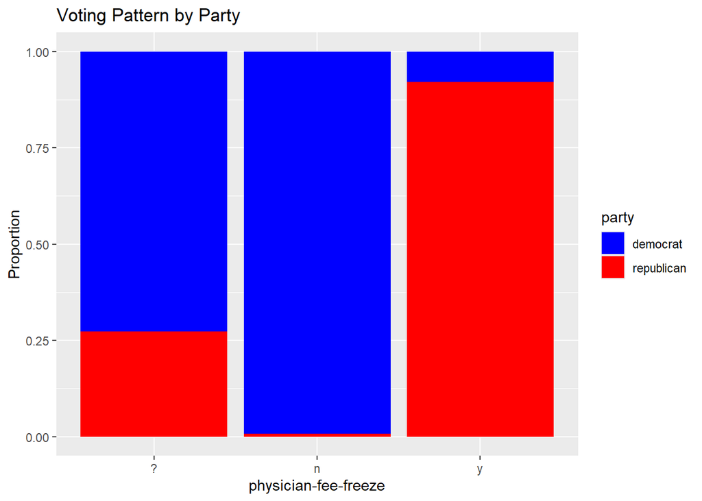

```r
ggplot(votes, aes(x = `physician-fee-freeze`, fill = party)) +
  geom_bar(position = "fill") +
  scale_fill_manual(values = c("democrat" = "blue", "republican" = "red")) +
  labs(title = "Voting Pattern by Party",
       y = "Proportion")
```

As I predicted, some of the voting records fall extremely along party lines! This means the voting record could be powerful in predicting party affiliation.

## 4.3 Missing Data

```r
colSums(is.na(votes))
```

```
##                         party           handicapped-infants
##                             0                             0
##    water-project-cost-sharing adoption-of-budget-resolution
##                             0                             0
##          physician-fee-freeze               el-salvador-aid
##                             0                             0
##   religious-groups-in-schools       anti-satellite-test-ban
##                             0                             0
##     aid-to-nicaraguan-contras                    mx-missile
##                             0                             0
##                   immigration  synfuels-corporation-cutback
##                             0                             0
##            education-spending        superfund-right-to-sue
##                             0                             0
##                         crime             duty-free-exports
##                             0                             0
##     export-administration-act
##                             0
```

No rows contain any missing values!

## 4.4 Validation Set Approach

```r
set.seed(1)

train_index <- sample(1:nrow(votes), nrow(votes)/2)

train <- votes[train_index, ]
test  <- votes[-train_index, ]
```

# 5. Creating Models

## 5.1 Logistic Regression

```r
glm_fit <- glm(party ~ ., data = train, family = binomial)
glm_probs <- predict(glm_fit, test, type = "response")
glm_pred <- ifelse(glm_probs > 0.5, "republican", "democrat")

# Accuracy
mean(glm_pred == test$party)
```

```
## [1] 0.9449541
```

```r
# Error Rate
mean(glm_pred != test$party)
```

```
## [1] 0.05504587
```

## 5.2 Linear Discriminant Analysis

```r
lda_fit <- lda(party ~ ., data = train)

lda_pred <- predict(lda_fit, test)$class

print("Accuracy:")
```

```
## [1] "Accuracy:"
```

```r
mean(lda_pred == test$party)
```

```
## [1] 0.9495413
```

```r
print("Error Rate:")
```

```
## [1] "Error Rate:"
```

```r
mean(lda_pred != test$party)
```

```
## [1] 0.05045872
```

## 5.3 Quadratic Discriminant Analysis

```r
#qda_fit <- qda(party ~ ., data = train)

#qda_pred <- predict(qda_fit, test)$class

# Accuracy
#mean(qda_pred == test$party)
# Error Rate
#mean(qda_pred != test$party)
```

QDA failed due to rank deficiency, likely caused by strong multicollinearity and our sparse categorical levels (3 categories). Because QDA requires estimation of separate covariance matrices for each class, it is more sensitive to these issues than LDA. Therefore, QDA was excluded from analysis.

## 5.4 Naive Bayes

```r
nb_fit <- naiveBayes(party ~ ., data = train)

nb_pred <- predict(nb_fit, test)

# Accuracy
mean(nb_pred == test$party)
```

```
## [1] 0.912844
```

```r
# Error Rate
mean(nb_pred != test$party)
```

```
## [1] 0.08715596
```

## 5.5 K-Nearest Neighbors (KNN)

```r
# Convert factors to numeric
train_x <- model.matrix(party ~ . -1, train)
test_x  <- model.matrix(party ~ . -1, test)

train_y <- train$party

set.seed(1)
knn_pred <- knn(train_x, test_x, train_y, k = 5)

# Accuracy
mean(knn_pred == test$party)
```

```
## [1] 0.9311927
```

```r
# Error Rate
mean(knn_pred != test$party)
```

```
## [1] 0.06880734
```

## 5.6 Model Comparison

```r
traintest_accuracy <- c(
  Logistic = mean(glm_pred == test$party),
  LDA      = mean(lda_pred == test$party),
  QDA      = NA,
  NaiveBayes = mean(nb_pred == test$party),
  KNN      = mean(knn_pred == test$party)
)

traintest_accuracy
```

```
##   Logistic        LDA        QDA NaiveBayes        KNN
##  0.9449541  0.9495413         NA  0.9128440  0.9311927
```

# 6. Cross-Validation Approach

```r
set.seed(1)

# Number of folds
k <- 10
n <- nrow(votes)
folds <- sample(rep(1:k, length.out = n))

cv_glm_acc <- numeric(k)
cv_lda_acc <- numeric(k)
cv_nb_acc  <- numeric(k)
cv_knn_acc <- numeric(k)
```

## 6.1 Logistic Regression

```r
for (i in 1:k) {
  # Split into training and validation sets
  train_cv <- votes[folds != i, ]
  val_cv   <- votes[folds == i, ]

  cv_glm_fit <- glm(party ~ ., data = train_cv, family = binomial)

  cv_glm_probs <- predict(cv_glm_fit, val_cv, type = "response")

  cv_glm_pred <- ifelse(cv_glm_probs > 0.5, "republican", "democrat")

  cv_glm_acc[i] <- mean(cv_glm_pred == val_cv$party)
}
# Accuracy
mean(cv_glm_acc)
```

```
## [1] 0.937685
```

```r
# Error Rate
mean(1 - cv_glm_acc)
```

```
## [1] 0.06231501
```

## 6.2 Linear Discriminant Analysis

```r
for (i in 1:k) {
  # Split into training and validation sets
  train_cv <- votes[folds != i, ]
  val_cv   <- votes[folds == i, ]

  cv_lda_fit <- lda(party ~ ., data = train_cv)

  cv_lda_pred <- predict(cv_lda_fit, val_cv)$class

  cv_lda_acc[i] <- mean(cv_lda_pred == val_cv$party)
}

# Accuracy
mean(cv_lda_acc)
```

```
## [1] 0.9540169
```

```r
# Error Rate
mean(1 - cv_lda_acc)
```

```
## [1] 0.04598309
```

## 6.3 Quadratic Discriminant Analysis

```r
#for (i in 1:k) {
  # Split into training and validation sets
  #train_cv <- votes[folds != i, ]
  #val_cv   <- votes[folds == i, ]

  #cv_qda_fit <- qda(party ~ ., data = train_cv)

  #cv_qda_pred <- predict(qda_fit, val_cv)$class

  #cv_qda_acc[i] <- mean(cv_qda_pred == val_cv$party)
#}

# Accuracy
#mean(cv_qda_acc)
# Error Rate
#mean(1 - cv_qda_acc)
```

QDA failed once again due to rank deficiency, likely caused by strong multicollinearity and our sparse categorical levels (3 categories). Because QDA requires estimation of separate covariance matrices for each class, it is more sensitive to these issues than LDA. Therefore, QDA was excluded from analysis.

## 6.3 Naive Bayes

```r
for (i in 1:k) {
  # Split into training and validation sets
  train_cv <- votes[folds != i, ]
  val_cv   <- votes[folds == i, ]

  cv_nb_fit <- naiveBayes(party ~ ., data = train_cv)

  cv_nb_pred <- predict(cv_nb_fit, val_cv)

  cv_nb_acc[i] <- mean(cv_nb_pred == val_cv$party)
}

# Accuracy
mean(cv_nb_acc)
```

```
## [1] 0.9012156
```

```r
# Error Rate
mean(1 - cv_nb_acc)
```

```
## [1] 0.09878436
```

## 6.4 K-Nearest Neighbors (KNN)

```r
for (i in 1:k) {
  # Split into training and validation sets
  train_cv <- votes[folds != i, ]
  val_cv   <- votes[folds == i, ]

  train_X <- model.matrix(party ~ . -1, train_cv)
  val_X   <- model.matrix(party ~ . -1, val_cv)
  train_Y <- train_cv$party

  cv_knn_pred <- knn(train_X, val_X, train_Y, k = 5)

  cv_knn_acc[i] <- mean(cv_knn_pred == val_cv$party)
}

# Accuracy
mean(cv_knn_acc)
```

```
## [1] 0.9309725
```

```r
# Error Rate
mean(1 - cv_knn_acc)
```

```
## [1] 0.06902748
```

## 6.5 Model Comparison

```r
cv_accuracy <- c(
  Logistic = mean(cv_glm_acc),
  LDA      = mean(cv_lda_acc),
  NaiveBayes = mean(cv_nb_acc),
  KNN      = mean(cv_knn_acc),
  QDA      = NA
)


cv_accuracy
```

```
##   Logistic        LDA NaiveBayes        KNN        QDA
##  0.9376850  0.9540169  0.9012156  0.9309725         NA
```

Just for a reminder, these were our validation set approach scores.

```r
traintest_accuracy
```

```
##   Logistic        LDA        QDA NaiveBayes        KNN
##  0.9449541  0.9495413         NA  0.9128440  0.9311927
```

# 7. Final Model Selection

This also beat KNN validation set and CV accuracy (both 93.1%).

Quadratic Discriminant Analysis (QDA) could not be fit due to rank deficiency issues.

Although Logistic Regression and KNN also achieved high validation accuracy, LDA combines both excellent predictive performance and interpretability, making it the most appropriate choice as the final model.

## 7.1 Confusion Matrix

```r
all_pred <- c()
all_actual <- c()

for (i in 1:k) {
  # Split data
  train_cv <- votes[folds != i, ]
  val_cv   <- votes[folds == i, ]

  # Fit model
  cv_lda_fit <- lda(party ~ ., data = train_cv)

  # Predict
  cv_lda_pred <- predict(cv_lda_fit, val_cv)$class

  # Store results
  all_pred <- c(all_pred, as.character(cv_lda_pred))
  all_actual <- c(all_actual, as.character(val_cv$party))
}

# Create one confusion matrix across all folds
conf_matrix <- table(Predicted = all_pred, Actual = all_actual)
conf_matrix
```

```
##             Actual
## Predicted    democrat republican
##   democrat        252          5
##   republican       15        163
```

## 7.2 Other Classification Metrics

Even though our classes are balanced and we can use the accuracy as a measure of model performance, let’s calculate the other common classification model metrics to investigate the exact performance of our final model.

```r
# Extract counts for Democrat
TP_dem <- conf_matrix["democrat", "democrat"]
FP_dem <- conf_matrix["democrat", "republican"]
FN_dem <- conf_matrix["republican", "democrat"]
TN_dem <- conf_matrix["republican", "republican"]

# Extract counts for Republican
TP_rep <- conf_matrix["republican", "republican"]
FP_rep <- conf_matrix["republican", "democrat"]
FN_rep <- conf_matrix["democrat", "republican"]
TN_rep <- conf_matrix["democrat", "democrat"]

# Accuracy
accuracy <- sum(diag(conf_matrix)) / sum(conf_matrix)
error_rate <- 1 - accuracy

# Democrat Metrics
precision_dem <- TP_dem / (TP_dem + FP_dem)
recall_dem    <- TP_dem / (TP_dem + FN_dem)
f1_dem        <- 2 * (precision_dem * recall_dem) / (precision_dem + recall_dem)

# Republican Metrics
precision_rep <- TP_rep / (TP_rep + FP_rep)
recall_rep    <- TP_rep / (TP_rep + FN_rep)
f1_rep        <- 2 * (precision_rep * recall_rep) / (precision_rep + recall_rep)

# Combine results
metrics <- data.frame(
  Class = c("Democrat", "Republican"),
  Precision = c(precision_dem, precision_rep),
  Recall = c(recall_dem, recall_rep),
  F1_Score = c(f1_dem, f1_rep)
)

metrics
```

```
##        Class Precision    Recall  F1_Score
## 1   Democrat 0.9805447 0.9438202 0.9618321
## 2 Republican 0.9157303 0.9702381 0.9421965
```

# 8. Conclusion

The analysis demonstrates that the voting records of U.S. House representatives are highly predictive of party affiliation. LDA, our final selected model, is able to accurately classify representatives as Democrats or Republicans based on their voting behavior with minimal error.

- Voting behavior is strongly structured and differs consistently between parties.
- Simpler linear methods like LDA or Logistic Regression perform better than methods that assume independence (Naive Bayes) or require complex covariance estimation (QDA).
- KNN performs reasonably well but does not offer interpretability or advantages over LDA in this setting.

Overall, LDA provides both accuracy and interpretability, making it the ideal model for classifying party affiliation from voting records.